# R Notebook

We’ve measured BMI as an outcome. But there are plenty of other outcome measure we could use to measure health and they have less problematic health stigma relationships. What can we identify? Janet Tomiyama suggests looking at other health measures from HINTS.

The following are in all relevant cycles which is good:

> In general, would you say your health is…
> - Has a doctor or other health professional ever told you that you had any of the following medical conditions: Diabetes or high blood sugar?
> - Has a doctor or other health professional ever told you that you had any of the following medical conditions: High blood pressure or hypertension?
> - Has a doctor or other health professional ever told you that you had any of the following medical conditions: A heart condition such as heart attack, angina or congestive heart failure?

Is there a reason we wouldn’t include more HINTS studies than only HINTS 5? We want to know about healthy eating behavior.

Oh… rurality. Only one HINTS study includes rurality; that’s HINTS5, Cycle 1 to 4. That’s what I use for the data here.

I’ll also add:

> - Have you ever been diagnosed as having cancer?

Pre-registration: https://osf.io/h98wp

So these items are:

- `GeneralHealth`
- `MedConditions_Diabetes`
- `MedConditions_HighBP`
- `MedConditions_HeartCondition`
- `EverHadCancer`

```r
library(mediation)
library(dplyr)
Sys.setenv(R_CONFIG_ACTIVE = Sys.info()["nodename"])
```

```r
source("HINTS_preprocessing.R")
hints5 <-get_hints5(paste0(config::get("hints_protected_data_folderpath"),"/"))
```

```
## [1] "hints5_cycle2_public.sav"
## [1] TRUE
## [1] "PR_RUCA_2010TRUE"
## [1] "RUC2013TRUE"
## [1] TRUE
## [1] TRUE
## [1] "hints5_cycle1_public.sav"
## [1] TRUE
## [1] "PR_RUCA_2010TRUE"
## [1] "RUC2013TRUE"
## [1] TRUE
## [1] TRUE
## [1] "hints5_cycle3_public.sav"
## [1] TRUE
## [1] "PR_RUCA_2010TRUE"
## [1] "RUC2013TRUE"
## [1] TRUE
## [1] TRUE
## [1] "hints5_cycle4_public.sav"
## [1] TRUE
## [1] "PR_RUCA_2010TRUE"
## [1] "RUC2013TRUE"
## [1] TRUE
## [1] TRUE
```

```r
boot_times<-10000
include_hispanic_status <- TRUE
if(include_hispanic_status){
  race_vars <- "RacePP+Hisp_Cat2"
}else{
  race_vars <- "RacePP"
}
```

```r
zscore <- function(x){
    return((x-mean(x,na.rm=TRUE))/sd(x,na.rm=TRUE))
  }
```

## 0.1 Data available from these variables

Let’s take a look at the qualitative data available.

```r
table(hints5$GeneralHealth_of) %>% cumsum / sum(!is.na(hints5$GeneralHealth_of))
```

```
## Excellent Very good      Good      Fair      Poor
## 0.1164388 0.4774746 0.8349820 0.9737887 1.0000000
```

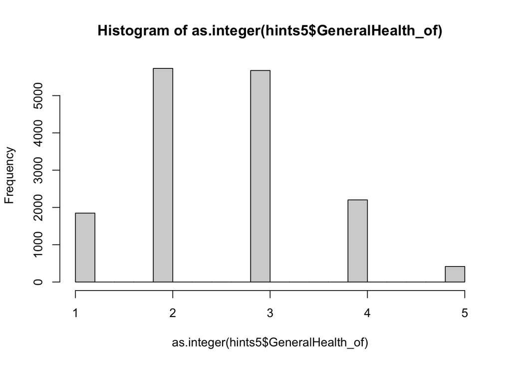

```r
hist(as.integer(hints5$GeneralHealth_of))
```

```r
hints5$GeneralHealth_i <- as.integer(hints5$GeneralHealth_of)
hints5$GeneralHealth_z <- zscore(hints5$GeneralHealth_i)
```

This is skewed, but not so skewed it hits my pre-registered criterion for transformation, so we will simply z-score it and proceed with that.

How about the other measures?

```r
for (dichot_var in c("MedConditions_Diabetes", "MedConditions_HighBP", "MedConditions_HeartCondition", "EverHadCancer")){
  print(dichot_var)
  print(table(hints5 %>% dplyr::select(dichot_var)))
  var_tally <- hints5 %>% dplyr::select(dichot_var) %>% .[[1]]
  print("proportion valid reaponses answering 'yes':")
  yes_tally = sum(var_tally=="Yes")
  no_tally = sum(var_tally=="No")
  print(yes_tally/(yes_tally+no_tally))
  #print(table(hints5 %>% select(dichot_var,"HINTSIsRural")))

}
```

```
## [1] "MedConditions_Diabetes"
## MedConditions_Diabetes
##                   Missing data (Not Ascertained)
##                                              357
##                    Missing data (Filter Missing)
##                                                0
##    Question answered in error (Commission Error)
##                                                0
##             Inapplicable, coded 2 in UseInternet
##                                                0
##                                              Yes
##                                             3368
##                                               No
##                                            12357
## Missing data (Web partial - Question Never Seen)
##                                               10
## [1] "proportion valid reaponses answering 'yes':"
## [1] 0.2141812
## [1] "MedConditions_HighBP"
## MedConditions_HighBP
##                   Missing data (Not Ascertained)
##                                              332
##                    Missing data (Filter Missing)
##                                                0
##    Question answered in error (Commission Error)
##                                                0
##             Inapplicable, coded 2 in UseInternet
##                                                0
##                                              Yes
##                                             7133
##                                               No
##                                             8617
## Missing data (Web partial - Question Never Seen)
##                                               10
## [1] "proportion valid reaponses answering 'yes':"
## [1] 0.4528889
## [1] "MedConditions_HeartCondition"
## MedConditions_HeartCondition
##                   Missing data (Not Ascertained)
##                                              292
```

[output cut: 11 more lines]

```
##                                               10
## [1] "proportion valid reaponses answering 'yes':"
## [1] 0.1017099
## [1] "EverHadCancer"
## EverHadCancer
##                   Missing data (Not Ascertained)
##                                              181
##                                              Yes
##                                             2579
##                                               No
##                                            13292
## Missing data (Web partial - Question Never Seen)
##                                               40
## [1] "proportion valid reaponses answering 'yes':"
## [1] 0.1624976
```

As per the pre-register, we will use the individual item MedConditions_HighBP, which has 45% of respondents answering yes, but rather than using MedConditions_Diabetes and MedConditions_HeartCondition, we will calculate an aggregate of all three measures and predict that aggregate. This code has now been moved to HINTS preprocessing.

```r
#dichotomize these variables so every value is either No, Yes, or NA.
```

## 0.2 Correlations between outcome variables and a few other important ones

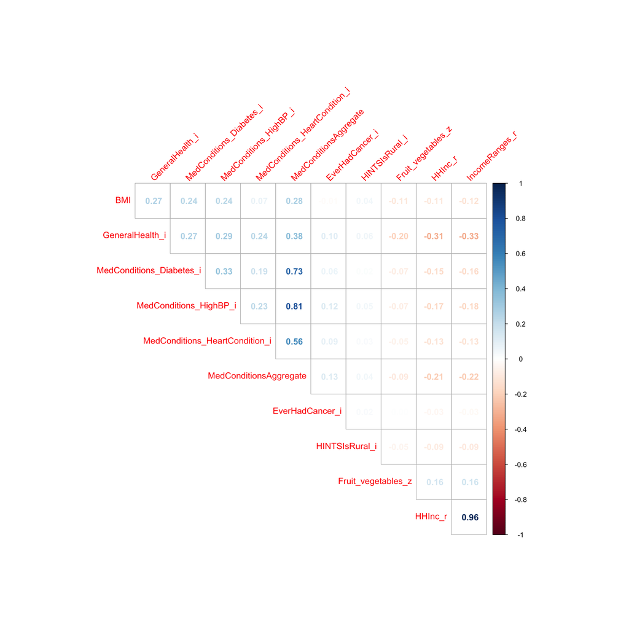

```r
data_to_correlate <- hints5[,c(
  "BMI","GeneralHealth_i","MedConditions_Diabetes_i","MedConditions_HighBP_i","MedConditions_HeartCondition_i","MedConditionsAggregate","EverHadCancer_i","HINTSIsRural_i","Fruit_vegetables_z",
  "HHInc_r","IncomeRanges_r"
  )]
cor_mat <- cor(data_to_correlate,use = "pairwise.complete.obs")
corrplot::corrplot(cor_mat,type="upper",diag=FALSE,method="number",tl.srt=45)
```

Some observations about the corrplot:

- **All four medical conditions we were interested in correlate better with self-reported General Health than they do with BMI.** This is a strong vote of confidence in favor of using self-reported general health over BMI. Two caveats are: (1) self-report variables tend to correlate better with related self-report variables than they do with, say, related behavioral variables, but perhaps just for various reporting bias reasons.(2) Perhaps general health self-report might have less of an advantage over BMI when it comes to reporting *future* health problems. That said, I take this as a moderate to strong endorsement of a self-report measure of general health over BMI in the context of population sampling.
- **BMI still has *some* relevance to medical conditions**, although you can’t make too much of a simple correlation.
- Differences in the strength of the objective health correlations with subjective health are related to their prevalence. High blood pressure is the most common medical condition included here (45%) and also has the strongest correlation with general health (0.29). That’s followed by diabetes (21%, 0.27), cancer (16%, 0.1), and heart conditions (10%, 0.24); cancer being the exception to the rule here. This more or less follows for correlations with BMI, too.

## 0.3 H1. There are poorer health outcomes for rural areas compared to urban ones

### 0.3.1 Result mentioned in text

To test this, we use regression.

So here, we’re testing general health for a start.

```r
#health_measures <- c("GeneralHealth", "MedConditions_Diabetes", "MedConditions_HighBP", "MedConditions_HeartCondition", EverHadCancer)
formula_rhs<-paste0("~HINTSIsRural_i+Age_c+I(Age_c^2)+",race_vars,"+Gender3C+filename")
```

#### 0.3.1.1 Self-rated health:

```r
formula_general <- paste0("GeneralHealth_i",formula_rhs)

print(formula_general)
```

```
## [1] "GeneralHealth_i~HINTSIsRural_i+Age_c+I(Age_c^2)+RacePP+Hisp_Cat2+Gender3C+filename"
```

```r
rural_disparity <- lm(eval(formula_general),hints5)

print_model_summary <- function(model){
  print(summary(model))
  conf_ints <- confint(model)
  if("glm" %in% class(model)){
    if (model$family$family=="binomial"){
      print(cbind(OR = exp(coef(model)),exp(conf_ints)))
      return()
    }
  }
  print(cbind(coef = coef(model),conf_ints))

}

print_model_summary(rural_disparity)
```

```
##
## Call:
## lm(formula = eval(formula_general), data = hints5)
##
## Residuals:
##      Min       1Q   Median       3Q      Max
## -2.37851 -0.62047  0.01039  0.54087  2.94713
##
## Coefficients:
##                                                          Estimate Std. Error
## (Intercept)                                             2.300e+00  2.099e-02
## HINTSIsRural_i                                          1.628e-01  2.200e-02
## Age_c                                                   1.093e-02  9.097e-04
## I(Age_c^2)                                             -1.502e-05  2.331e-05
## RacePPBlack                                             3.110e-01  2.145e-02
## RacePPMissing data (Not Ascertained)                    8.065e-02  3.691e-02
## RacePPMultiple races selected                           2.773e-01  3.988e-02
## RacePPChinese                                           1.242e-01  6.987e-02
## RacePPFilipino                                          1.945e-01  7.734e-02
## RacePPAsian Indian                                     -3.907e-02  8.061e-02
## RacePPOther Asian                                       1.430e-01  8.247e-02
## RacePPAmerican Indian or Alaska Native                  2.923e-01  9.093e-02
## RacePPPacific Islander                                  3.969e-01  1.038e-01
## RacePPVietnamese                                        1.721e-01  1.198e-01
## RacePPMissing data (Web partial - Question Never Seen) -1.028e-01  1.665e-01
## RacePPKorean                                            1.599e-01  1.503e-01
## RacePPJapanese                                         -1.620e-01  1.750e-01
## Hisp_Cat2Unknown                                        1.484e-01  3.067e-02
## Hisp_Cat2Mexican                                        3.371e-01  3.216e-02
## Hisp_Cat2Other Hispanic                                 1.399e-01  3.708e-02
## Hisp_Cat2Puerto Rican                                   2.358e-01  6.317e-02
## Hisp_Cat2Multiple Hispanic ethnicities selected         2.057e-01  9.057e-02
## Hisp_Cat2Cuban                                         -1.223e-01  9.382e-02
## Gender3CMale                                           -3.506e-02  1.570e-02
## Gender3CMissingOrMultiple                               8.499e-03  3.345e-02
## filenamehints5_cycle2_public.sav                       -4.936e-02  2.295e-02
## filenamehints5_cycle3_public.sav                       -3.395e-02  2.100e-02
## filenamehints5_cycle4_public.sav                       -2.356e-02  2.254e-02
##                                                        t value Pr(>|t|)
## (Intercept)                                            109.561  < 2e-16 ***
```

[output cut: 107 more lines]

```
## RacePPVietnamese                                        4.068847e-01
## RacePPMissing data (Web partial - Question Never Seen)  2.234286e-01
## RacePPKorean                                            4.544958e-01
## RacePPJapanese                                          1.809403e-01
## Hisp_Cat2Unknown                                        2.084867e-01
## Hisp_Cat2Mexican                                        4.001718e-01
## Hisp_Cat2Other Hispanic                                 2.125432e-01
## Hisp_Cat2Puerto Rican                                   3.596398e-01
## Hisp_Cat2Multiple Hispanic ethnicities selected         3.832774e-01
## Hisp_Cat2Cuban                                          6.159786e-02
## Gender3CMale                                           -4.292879e-03
## Gender3CMissingOrMultiple                               7.405689e-02
## filenamehints5_cycle2_public.sav                       -4.374081e-03
## filenamehints5_cycle3_public.sav                        7.207026e-03
## filenamehints5_cycle4_public.sav                        2.062535e-02
```

```r
formula_hbp <- paste0("MedConditions_HighBP_i",formula_rhs)
print(formula_hbp)
```

```
## [1] "MedConditions_HighBP_i~HINTSIsRural_i+Age_c+I(Age_c^2)+RacePP+Hisp_Cat2+Gender3C+filename"
```

```r
rural_disparity <- glm(eval(formula_hbp),hints5, family = "binomial")


print_model_summary(rural_disparity)
```

```
##
## Call:
## glm(formula = eval(formula_hbp), family = "binomial", data = hints5)
##
## Deviance Residuals:
##     Min       1Q   Median       3Q      Max
## -2.1714  -1.0079  -0.4135   1.0016   2.5837
##
## Coefficients:
##                                                          Estimate Std. Error
## (Intercept)                                            -1.709e+00  5.631e-02
## HINTSIsRural_i                                          2.032e-01  5.252e-02
## Age_c                                                   7.843e-02  2.975e-03
## I(Age_c^2)                                             -5.376e-04  6.778e-05
## RacePPBlack                                             8.775e-01  5.259e-02
## RacePPMissing data (Not Ascertained)                   -2.303e-02  9.035e-02
## RacePPMultiple races selected                           3.083e-01  9.810e-02
## RacePPChinese                                          -4.829e-01  1.886e-01
## RacePPFilipino                                          6.023e-01  1.845e-01
## RacePPAsian Indian                                     -1.411e-01  2.156e-01
## RacePPOther Asian                                      -1.671e-01  2.130e-01
## RacePPAmerican Indian or Alaska Native                  4.388e-01  2.192e-01
## RacePPPacific Islander                                  2.343e-01  2.599e-01
## RacePPVietnamese                                       -1.272e-01  2.989e-01
## RacePPMissing data (Web partial - Question Never Seen)  5.221e-02  4.638e-01
## RacePPKorean                                           -1.104e-01  3.614e-01
## RacePPJapanese                                          4.532e-01  4.231e-01
## Hisp_Cat2Unknown                                        1.749e-01  7.446e-02
## Hisp_Cat2Mexican                                        1.587e-01  8.071e-02
## Hisp_Cat2Other Hispanic                                -6.364e-02  9.176e-02
## Hisp_Cat2Puerto Rican                                   2.529e-01  1.493e-01
## Hisp_Cat2Multiple Hispanic ethnicities selected         1.718e-01  2.281e-01
## Hisp_Cat2Cuban                                          1.426e-01  2.339e-01
## Gender3CMale                                            2.666e-01  3.799e-02
## Gender3CMissingOrMultiple                              -7.571e-03  8.009e-02
## filenamehints5_cycle2_public.sav                        1.783e-02  5.547e-02
## filenamehints5_cycle3_public.sav                       -2.854e-02  5.074e-02
## filenamehints5_cycle4_public.sav                       -4.542e-02  5.456e-02
##                                                        z value Pr(>|z|)
## (Intercept)                                            -30.347  < 2e-16 ***
```

[output cut: 23 more lines]

```
## Gender3CMissingOrMultiple                               -0.095  0.92468
## filenamehints5_cycle2_public.sav                         0.321  0.74785
## filenamehints5_cycle3_public.sav                        -0.562  0.57378
## filenamehints5_cycle4_public.sav                        -0.832  0.40515
## ---
## Signif. codes:  0 '***' 0.001 '**' 0.01 '*' 0.05 '.' 0.1 ' ' 1
##
## (Dispersion parameter for binomial family taken to be 1)
##
##     Null deviance: 21102  on 15324  degrees of freedom
## Residual deviance: 17925  on 15297  degrees of freedom
##   (767 observations deleted due to missingness)
## AIC: 17981
##
## Number of Fisher Scoring iterations: 4
```

```
##                                                               OR     2.5 %
## (Intercept)                                            0.1810745 0.1620614
## HINTSIsRural_i                                         1.2252581 1.1054720
## Age_c                                                  1.0815898 1.0753598
## I(Age_c^2)                                             0.9994626 0.9993296
## RacePPBlack                                            2.4047691 2.1698366
## RacePPMissing data (Not Ascertained)                   0.9772330 0.8184048
## RacePPMultiple races selected                          1.3610886 1.1224898
## RacePPChinese                                          0.6169862 0.4233399
## RacePPFilipino                                         1.8263199 1.2737079
## RacePPAsian Indian                                     0.8684108 0.5640795
## RacePPOther Asian                                      0.8461047 0.5529723
## RacePPAmerican Indian or Alaska Native                 1.5508341 1.0086437
## RacePPPacific Islander                                 1.2640496 0.7546671
## RacePPVietnamese                                       0.8805899 0.4836721
## RacePPMissing data (Web partial - Question Never Seen) 1.0535957 0.3959157
## RacePPKorean                                           0.8955203 0.4366241
## RacePPJapanese                                         1.5732681 0.6901760
## Hisp_Cat2Unknown                                       1.1910999 1.0299205
## Hisp_Cat2Mexican                                       1.1719819 1.0001414
## Hisp_Cat2Other Hispanic                                0.9383436 0.7833011
## Hisp_Cat2Puerto Rican                                  1.2877095 0.9600524
## Hisp_Cat2Multiple Hispanic ethnicities selected        1.1874548 0.7567338
## Hisp_Cat2Cuban                                         1.1532650 0.7266919
## Gender3CMale                                           1.3055649 1.2119170
## Gender3CMissingOrMultiple                              0.9924575 0.8482942
## filenamehints5_cycle2_public.sav                       1.0179909 0.9131257
## filenamehints5_cycle3_public.sav                       0.9718626 0.8798597
## filenamehints5_cycle4_public.sav                       0.9555969 0.8586718
##                                                           97.5 %
## (Intercept)                                            0.2020934
## HINTSIsRural_i                                         1.3582346
## Age_c                                                  1.0879744
## I(Age_c^2)                                             0.9995951
## RacePPBlack                                            2.6666484
## RacePPMissing data (Not Ascertained)                   1.1663267
## RacePPMultiple races selected                          1.6491442
## RacePPChinese                                          0.8880752
## RacePPFilipino                                         2.6282688
## RacePPAsian Indian                                     1.3156431
## RacePPOther Asian                                      1.2766242
## RacePPAmerican Indian or Alaska Native                 2.3864089
## RacePPPacific Islander                                 2.0964479
## RacePPVietnamese                                       1.5691515
## RacePPMissing data (Web partial - Question Never Seen) 2.4983901
## RacePPKorean                                           1.8174288
## RacePPJapanese                                         3.6804571
## Hisp_Cat2Unknown                                       1.3790873
## Hisp_Cat2Mexican                                       1.3724666
## Hisp_Cat2Other Hispanic                                1.1225443
## Hisp_Cat2Puerto Rican                                  1.7248322
## Hisp_Cat2Multiple Hispanic ethnicities selected        1.8536986
## Hisp_Cat2Cuban                                         1.8217924
## Gender3CMale                                           1.4065456
## Gender3CMissingOrMultiple                              1.1612253
## filenamehints5_cycle2_public.sav                       1.1349084
## filenamehints5_cycle3_public.sav                       1.0734923
## filenamehints5_cycle4_public.sav                       1.0634496
```

Now we use the aggregate value.

```r
formula_hbp <- paste0("MedConditionsAggregate",formula_rhs)
print(formula_hbp)
```

```
## [1] "MedConditionsAggregate~HINTSIsRural_i+Age_c+I(Age_c^2)+RacePP+Hisp_Cat2+Gender3C+filename"
```

```r
rural_disparity <- lm(formula_hbp,hints5)



print_model_summary(rural_disparity)
```

```
##
## Call:
## lm(formula = formula_hbp, data = hints5)
##
## Residuals:
##     Min      1Q  Median      3Q     Max
## -1.8106 -0.5738 -0.1175  0.4440  3.0834
##
## Coefficients:
##                                                          Estimate Std. Error
## (Intercept)                                             2.071e-01  1.781e-02
## HINTSIsRural_i                                          7.281e-02  1.875e-02
## Age_c                                                   2.231e-02  7.709e-04
## I(Age_c^2)                                             -2.475e-05  1.989e-05
## RacePPBlack                                             3.201e-01  1.832e-02
## RacePPMissing data (Not Ascertained)                    9.392e-03  3.160e-02
## RacePPMultiple races selected                           1.048e-01  3.380e-02
## RacePPChinese                                          -3.106e-02  5.902e-02
## RacePPFilipino                                          2.560e-01  6.558e-02
## RacePPAsian Indian                                      3.594e-02  6.841e-02
## RacePPOther Asian                                       8.431e-02  6.919e-02
## RacePPAmerican Indian or Alaska Native                  2.585e-01  7.694e-02
## RacePPPacific Islander                                  1.913e-01  8.911e-02
## RacePPVietnamese                                        1.293e-01  1.009e-01
## RacePPMissing data (Web partial - Question Never Seen) -1.136e-03  1.424e-01
## RacePPKorean                                            3.333e-02  1.283e-01
## RacePPJapanese                                         -9.929e-02  1.500e-01
## Hisp_Cat2Unknown                                        1.247e-01  2.664e-02
## Hisp_Cat2Mexican                                        1.588e-01  2.729e-02
## Hisp_Cat2Other Hispanic                                 4.673e-02  3.150e-02
## Hisp_Cat2Puerto Rican                                   1.660e-01  5.334e-02
## Hisp_Cat2Multiple Hispanic ethnicities selected         2.309e-01  7.593e-02
## Hisp_Cat2Cuban                                         -3.528e-02  8.067e-02
## Gender3CMale                                            1.331e-01  1.333e-02
## Gender3CMissingOrMultiple                               3.009e-02  2.856e-02
## filenamehints5_cycle2_public.sav                        4.066e-03  1.954e-02
## filenamehints5_cycle3_public.sav                        1.827e-03  1.784e-02
## filenamehints5_cycle4_public.sav                        6.003e-03  1.914e-02
##                                                        t value Pr(>|t|)
## (Intercept)                                             11.629  < 2e-16 ***
```

[output cut: 107 more lines]

```
## RacePPVietnamese                                       3.270865e-01
## RacePPMissing data (Web partial - Question Never Seen) 2.779990e-01
## RacePPKorean                                           2.847744e-01
## RacePPJapanese                                         1.948018e-01
## Hisp_Cat2Unknown                                       1.768827e-01
## Hisp_Cat2Mexican                                       2.122938e-01
## Hisp_Cat2Other Hispanic                                1.084815e-01
## Hisp_Cat2Puerto Rican                                  2.705439e-01
## Hisp_Cat2Multiple Hispanic ethnicities selected        3.797684e-01
## Hisp_Cat2Cuban                                         1.228469e-01
## Gender3CMale                                           1.592485e-01
## Gender3CMissingOrMultiple                              8.607365e-02
## filenamehints5_cycle2_public.sav                       4.235764e-02
## filenamehints5_cycle3_public.sav                       3.680252e-02
## filenamehints5_cycle4_public.sav                       4.351624e-02
```

Finally, how do we do on the cancer score?

```r
table(hints5$EverHadCancer_i,hints5$HINTSIsRural)
```

```
##
##     FALSE  TRUE
##   0 11538  1753
##   1  2186   393
```

```r
formula_cancer <- paste0("EverHadCancer_i",formula_rhs)
print(formula_cancer)
```

```
## [1] "EverHadCancer_i~HINTSIsRural_i+Age_c+I(Age_c^2)+RacePP+Hisp_Cat2+Gender3C+filename"
```

```r
rural_disparity <- glm(eval(formula_cancer),hints5, family = "binomial")



print_model_summary(rural_disparity)
```

```
##
## Call:
## glm(formula = eval(formula_cancer), family = "binomial", data = hints5)
##
## Deviance Residuals:
##     Min       1Q   Median       3Q      Max
## -1.1503  -0.6743  -0.4436  -0.1996   3.4311
##
## Coefficients:
##                                                          Estimate Std. Error
## (Intercept)                                            -3.013e+00  8.958e-02
## HINTSIsRural_i                                         -7.732e-02  6.469e-02
## Age_c                                                   8.544e-02  5.214e-03
## I(Age_c^2)                                             -6.247e-04  9.556e-05
## RacePPBlack                                            -5.345e-01  7.111e-02
## RacePPMissing data (Not Ascertained)                   -3.147e-01  1.290e-01
## RacePPMultiple races selected                           5.479e-03  1.313e-01
## RacePPChinese                                          -1.025e+00  3.095e-01
## RacePPFilipino                                         -1.150e+00  3.351e-01
## RacePPAsian Indian                                     -1.044e+00  3.997e-01
## RacePPOther Asian                                      -7.351e-01  3.441e-01
## RacePPAmerican Indian or Alaska Native                  2.329e-01  2.888e-01
## RacePPPacific Islander                                 -7.496e-01  4.794e-01
## RacePPVietnamese                                       -1.320e+00  6.047e-01
## RacePPMissing data (Web partial - Question Never Seen) -8.952e+00  1.103e+02
## RacePPKorean                                           -2.362e+00  1.021e+00
## RacePPJapanese                                          1.001e-01  4.824e-01
## Hisp_Cat2Unknown                                       -8.278e-02  8.541e-02
## Hisp_Cat2Mexican                                       -6.889e-01  1.293e-01
## Hisp_Cat2Other Hispanic                                -7.933e-01  1.511e-01
## Hisp_Cat2Puerto Rican                                  -4.926e-01  2.310e-01
## Hisp_Cat2Multiple Hispanic ethnicities selected        -3.971e-01  3.363e-01
## Hisp_Cat2Cuban                                         -5.977e-02  2.906e-01
## Gender3CMale                                           -4.278e-02  4.846e-02
## Gender3CMissingOrMultiple                               5.945e-02  9.786e-02
## filenamehints5_cycle2_public.sav                        8.417e-02  7.099e-02
## filenamehints5_cycle3_public.sav                        2.345e-02  6.547e-02
## filenamehints5_cycle4_public.sav                        6.729e-02  6.997e-02
##                                                        z value Pr(>|z|)
## (Intercept)                                            -33.636  < 2e-16 ***
```

[output cut: 23 more lines]

```
## Gender3CMissingOrMultiple                                0.607 0.543533
## filenamehints5_cycle2_public.sav                         1.186 0.235750
## filenamehints5_cycle3_public.sav                         0.358 0.720174
## filenamehints5_cycle4_public.sav                         0.962 0.336192
## ---
## Signif. codes:  0 '***' 0.001 '**' 0.01 '*' 0.05 '.' 0.1 ' ' 1
##
## (Dispersion parameter for binomial family taken to be 1)
##
##     Null deviance: 13782  on 15519  degrees of freedom
## Residual deviance: 12139  on 15492  degrees of freedom
##   (572 observations deleted due to missingness)
## AIC: 12195
##
## Number of Fisher Scoring iterations: 10
```

```
##                                                                  OR       2.5 %
## (Intercept)                                            0.0491305645 0.041106538
## HINTSIsRural_i                                         0.9255937328 0.814550384
## Age_c                                                  1.0891955539 1.078343220
## I(Age_c^2)                                             0.9993754653 0.999185839
## RacePPBlack                                            0.5859500549 0.508945780
## RacePPMissing data (Not Ascertained)                   0.7299808924 0.564846858
## RacePPMultiple races selected                          1.0054940337 0.772551567
## RacePPChinese                                          0.3587974920 0.185734988
## RacePPFilipino                                         0.3165154300 0.153894245
## RacePPAsian Indian                                     0.3519453169 0.146311887
## RacePPOther Asian                                      0.4794534231 0.229739032
## RacePPAmerican Indian or Alaska Native                 1.2622414783 0.693810291
## RacePPPacific Islander                                 0.4725605738 0.161696295
## RacePPVietnamese                                       0.2671738965 0.064086997
## RacePPMissing data (Web partial - Question Never Seen) 0.0001294804          NA
## RacePPKorean                                           0.0942645488 0.005267768
## RacePPJapanese                                         1.1052712476 0.393374217
## Hisp_Cat2Unknown                                       0.9205573846 0.777485691
## Hisp_Cat2Mexican                                       0.5021271452 0.387052941
## Hisp_Cat2Other Hispanic                                0.4523297293 0.332862646
## Hisp_Cat2Puerto Rican                                  0.6110417798 0.379187425
## Hisp_Cat2Multiple Hispanic ethnicities selected        0.6722337492 0.329995638
## Hisp_Cat2Cuban                                         0.9419798807 0.516240458
## Gender3CMale                                           0.9581229066 0.871199409
## Gender3CMissingOrMultiple                              1.0612477740 0.874286754
## filenamehints5_cycle2_public.sav                       1.0878088456 0.946636144
## filenamehints5_cycle3_public.sav                       1.0237313542 0.900781559
## filenamehints5_cycle4_public.sav                       1.0696078966 0.932701079
##                                                              97.5 %
## (Intercept)                                              0.05840672
## HINTSIsRural_i                                           1.04972395
## Age_c                                                    1.10061650
## I(Age_c^2)                                               0.99956031
## RacePPBlack                                              0.67262964
## RacePPMissing data (Not Ascertained)                     0.93677857
## RacePPMultiple races selected                            1.29355006
## RacePPChinese                                            0.63163347
## RacePPFilipino                                           0.58047452
## RacePPAsian Indian                                       0.71761136
## RacePPOther Asian                                        0.89743288
## RacePPAmerican Indian or Alaska Native                   2.16752609
## RacePPPacific Islander                                   1.10089646
## RacePPVietnamese                                         0.74630795
## RacePPMissing data (Web partial - Question Never Seen) 229.72212116
## RacePPKorean                                             0.44613875
## RacePPJapanese                                           2.69343554
## Hisp_Cat2Unknown                                         1.08679652
## Hisp_Cat2Mexican                                         0.64297227
## Hisp_Cat2Other Hispanic                                  0.60256855
## Hisp_Cat2Puerto Rican                                    0.94139471
## Hisp_Cat2Multiple Hispanic ethnicities selected          1.24826751
## Hisp_Cat2Cuban                                           1.62452303
## Gender3CMale                                             1.05345700
## Gender3CMissingOrMultiple                                1.28326453
## filenamehints5_cycle2_public.sav                         1.25040938
## filenamehints5_cycle3_public.sav                         1.16439827
## filenamehints5_cycle4_public.sav                         1.22711120
```

Overall, that’s a strong result, and we can proceed to look at mediation factors.

## 0.4 Rural health outcomes are mediated by fruit and vegetable consumption.

```r
run_HINTS_mediation <- function(outcome,mediator,is_logistic=FALSE){
  data_to_measure <- hints5[!is.na(hints5[[outcome]]),] %>% filter(Gender3C %in% c("Male","Female"))
  mb_formula <<-paste0(mediator,"~HINTSIsRural_i+Age_c+I(Age_c^2)+",race_vars,"+Gender3C+filename")
  mb <<- lm(eval(mb_formula),data_to_measure)
  mc_formula<<- paste0(outcome, "~", mediator, "+HINTSIsRural_i+Age_c+I(Age_c^2)+",race_vars,"+Gender3C+filename")
  #mc_direct <- paste0(outcome, "~HINTSIsRural_i+Age_c+I(Age_c^2)+RacePP+Gender3C+filename")
  ## these have to be global scope because they have to be accessed within the mediate function. d
  if(is_logistic){
    mc <<- glm(eval(mc_formula), data=data_to_measure,family="binomial")
    #m_direct <- glm(eval(mc_direct), data=data_to_measure,family="binomial")
  }else{
    mc <<- lm(eval(mc_formula), data=data_to_measure)
    #m_direct <- lm(eval(mc_direct), data=data_to_measure)
  }
  #print(mc_direct)
  #print(summary(m_direct))


  print(mb_formula)
  #print(summary(mb))
  print(mc_formula)

  mediation_model <- mediate(mb,mc,sims=boot_times, boot=TRUE,boot.ci.type = "bca",
                                  treat="HINTSIsRural_i",mediator=mediator)

  print(summary(mc))
  print(summary(mediation_model))
  return(mediation_model)

}
```

```r
library(mediation)
# GeneralHealth_i #linear
# MedConditions_HighBP_i #logistic
# MedConditionsAggregate #linear
# EverHadCancer_i #linear

set.seed(7042643)

mediation_result1 = run_HINTS_mediation("GeneralHealth_i", "Fruit_vegetables_z", is_logistic=FALSE)
```

```
## [1] "Fruit_vegetables_z~HINTSIsRural_i+Age_c+I(Age_c^2)+RacePP+Hisp_Cat2+Gender3C+filename"
## [1] "GeneralHealth_i~Fruit_vegetables_z+HINTSIsRural_i+Age_c+I(Age_c^2)+RacePP+Hisp_Cat2+Gender3C+filename"
```

```
## Running nonparametric bootstrap
```

```
##
## Call:
## lm(formula = eval(mc_formula), data = data_to_measure)
##
## Residuals:
##     Min      1Q  Median      3Q     Max
## -2.4795 -0.6103 -0.0204  0.5451  3.1975
##
## Coefficients:
##                                                   Estimate Std. Error t value
## (Intercept)                                      2.340e+00  2.901e-02  80.646
## Fruit_vegetables_z                              -1.944e-01  1.146e-02 -16.957
## HINTSIsRural_i                                   1.409e-01  3.392e-02   4.154
## Age_c                                            1.167e-02  1.402e-03   8.321
## I(Age_c^2)                                      -7.109e-05  3.705e-05  -1.919
## RacePPBlack                                      3.076e-01  3.267e-02   9.414
## RacePPMissing data (Not Ascertained)             1.458e-01  6.245e-02   2.335
## RacePPMultiple races selected                    3.368e-01  6.017e-02   5.597
## RacePPChinese                                    1.127e-01  1.045e-01   1.079
## RacePPFilipino                                   3.811e-01  1.169e-01   3.259
## RacePPAsian Indian                              -1.179e-01  1.193e-01  -0.989
## RacePPOther Asian                                2.398e-01  1.499e-01   1.599
## RacePPAmerican Indian or Alaska Native           5.555e-01  1.578e-01   3.520
## RacePPPacific Islander                           3.696e-01  1.704e-01   2.169
## RacePPVietnamese                                 5.480e-02  1.634e-01   0.335
## RacePPKorean                                     1.355e-01  1.818e-01   0.746
## RacePPJapanese                                  -7.670e-02  2.031e-01  -0.378
## Hisp_Cat2Unknown                                 1.548e-01  5.201e-02   2.976
## Hisp_Cat2Mexican                                 2.989e-01  4.882e-02   6.123
## Hisp_Cat2Other Hispanic                          8.516e-02  5.720e-02   1.489
## Hisp_Cat2Puerto Rican                            2.314e-01  9.916e-02   2.333
## Hisp_Cat2Multiple Hispanic ethnicities selected  1.396e-01  1.380e-01   1.011
## Hisp_Cat2Cuban                                  -1.127e-01  1.423e-01  -0.792
## Gender3CMale                                    -5.400e-02  2.305e-02  -2.343
## filenamehints5_cycle3_public.sav                -5.812e-02  2.563e-02  -2.268
##                                                 Pr(>|t|)
## (Intercept)                                      < 2e-16 ***
## Fruit_vegetables_z                               < 2e-16 ***
## HINTSIsRural_i                                  3.31e-05 ***
## Age_c                                            < 2e-16 ***
```

[output cut: 31 more lines]

```
##
## Nonparametric Bootstrap Confidence Intervals with the BCa Method
##
##                Estimate 95% CI Lower 95% CI Upper p-value
## ACME             0.0297       0.0156         0.04  <2e-16 ***
## ADE              0.1409       0.0733         0.21  <2e-16 ***
## Total Effect     0.1705       0.1012         0.24  <2e-16 ***
## Prop. Mediated   0.1739       0.0983         0.35  <2e-16 ***
## ---
## Signif. codes:  0 '***' 0.001 '**' 0.01 '*' 0.05 '.' 0.1 ' ' 1
##
## Sample Size Used: 6477
##
##
## Simulations: 10000
```

```r
# GeneralHealth_i #linear
# MedConditions_HighBP_i #logistic
# MedConditionsAggregate #linear
# EverHadCancer_i #linear

set.seed(7422649)

mediation_result2 = run_HINTS_mediation("MedConditions_HighBP_i", "Fruit_vegetables_z", is_logistic=TRUE)
```

```
## [1] "Fruit_vegetables_z~HINTSIsRural_i+Age_c+I(Age_c^2)+RacePP+Hisp_Cat2+Gender3C+filename"
## [1] "MedConditions_HighBP_i~Fruit_vegetables_z+HINTSIsRural_i+Age_c+I(Age_c^2)+RacePP+Hisp_Cat2+Gender3C+filename"
```

```
## Running nonparametric bootstrap
```

```
##
## Call:
## glm(formula = eval(mc_formula), family = "binomial", data = data_to_measure)
##
## Deviance Residuals:
##     Min       1Q   Median       3Q      Max
## -2.0927  -0.9877  -0.4166   0.9953   2.5523
##
## Coefficients:
##                                                   Estimate Std. Error z value
## (Intercept)                                     -1.7633657  0.0816889 -21.586
## Fruit_vegetables_z                              -0.1234556  0.0286795  -4.305
## HINTSIsRural_i                                   0.1782370  0.0837451   2.128
## Age_c                                            0.0799819  0.0047372  16.884
## I(Age_c^2)                                      -0.0005037  0.0001112  -4.531
## RacePPBlack                                      0.8275740  0.0816631  10.134
## RacePPMissing data (Not Ascertained)             0.0092708  0.1572421   0.059
## RacePPMultiple races selected                    0.3674472  0.1526872   2.407
## RacePPChinese                                   -0.3026728  0.2848535  -1.063
## RacePPFilipino                                   0.6001758  0.2857304   2.100
## RacePPAsian Indian                               0.2763628  0.3152631   0.877
## RacePPOther Asian                                0.1393411  0.3920102   0.355
## RacePPAmerican Indian or Alaska Native           0.6557470  0.3922071   1.672
## RacePPPacific Islander                          -0.1145657  0.4465162  -0.257
## RacePPVietnamese                                 0.1236711  0.4192803   0.295
## RacePPKorean                                    -0.0376680  0.4499927  -0.084
## RacePPJapanese                                   0.6803723  0.5183398   1.313
## Hisp_Cat2Unknown                                 0.2878993  0.1307141   2.203
## Hisp_Cat2Mexican                                 0.1338383  0.1259808   1.062
## Hisp_Cat2Other Hispanic                         -0.0184659  0.1467204  -0.126
## Hisp_Cat2Puerto Rican                            0.2465048  0.2371351   1.040
## Hisp_Cat2Multiple Hispanic ethnicities selected  0.2816865  0.3628994   0.776
## Hisp_Cat2Cuban                                   0.2907831  0.3665988   0.793
## Gender3CMale                                     0.2666746  0.0572980   4.654
## filenamehints5_cycle3_public.sav                -0.0585643  0.0637535  -0.919
##                                                 Pr(>|z|)
## (Intercept)                                      < 2e-16 ***
## Fruit_vegetables_z                              1.67e-05 ***
## HINTSIsRural_i                                    0.0333 *
## Age_c                                            < 2e-16 ***
```

[output cut: 41 more lines]

```
## ADE (control)             0.03534      0.00208         0.07   0.039 *
## ADE (treated)             0.03535      0.00208         0.07   0.039 *
## Total Effect              0.03912      0.00601         0.07   0.022 *
## Prop. Mediated (control)  0.09636      0.03442         0.78   0.022 *
## Prop. Mediated (treated)  0.09670      0.03457         0.79   0.022 *
## ACME (average)            0.00378      0.00172         0.01  <2e-16 ***
## ADE (average)             0.03535      0.00208         0.07   0.039 *
## Prop. Mediated (average)  0.09653      0.03450         0.78   0.022 *
## ---
## Signif. codes:  0 '***' 0.001 '**' 0.01 '*' 0.05 '.' 0.1 ' ' 1
##
## Sample Size Used: 6439
##
##
## Simulations: 10000
```

```r
# GeneralHealth_i #linear
# MedConditions_HighBP_i #logistic
# MedConditionsAggregate #linear
# EverHadCancer_i #linear



set.seed(4194457)
mediation_result = run_HINTS_mediation("MedConditionsAggregate", "Fruit_vegetables_z", is_logistic=FALSE)
```

```
## [1] "Fruit_vegetables_z~HINTSIsRural_i+Age_c+I(Age_c^2)+RacePP+Hisp_Cat2+Gender3C+filename"
## [1] "MedConditionsAggregate~Fruit_vegetables_z+HINTSIsRural_i+Age_c+I(Age_c^2)+RacePP+Hisp_Cat2+Gender3C+filename"
```

```
## Running nonparametric bootstrap
```

```
##
## Call:
## lm(formula = eval(mc_formula), data = data_to_measure)
##
## Residuals:
##     Min      1Q  Median      3Q     Max
## -1.6963 -0.5627 -0.1089  0.4161  3.1304
##
## Coefficients:
##                                                   Estimate Std. Error t value
## (Intercept)                                      1.974e-01  2.477e-02   7.971
## Fruit_vegetables_z                              -5.180e-02  9.780e-03  -5.297
## HINTSIsRural_i                                   6.509e-02  2.911e-02   2.236
## Age_c                                            2.200e-02  1.195e-03  18.405
## I(Age_c^2)                                      -6.394e-06  3.175e-05  -0.201
## RacePPBlack                                      3.157e-01  2.809e-02  11.240
## RacePPMissing data (Not Ascertained)             2.808e-02  5.321e-02   0.528
## RacePPMultiple races selected                    1.456e-01  5.133e-02   2.836
## RacePPChinese                                    8.572e-03  8.857e-02   0.097
## RacePPFilipino                                   2.758e-01  9.991e-02   2.760
## RacePPAsian Indian                               1.128e-01  1.011e-01   1.116
## RacePPOther Asian                                1.975e-01  1.254e-01   1.574
## RacePPAmerican Indian or Alaska Native           3.460e-01  1.338e-01   2.586
## RacePPPacific Islander                           3.360e-01  1.495e-01   2.247
## RacePPVietnamese                                 1.280e-01  1.385e-01   0.924
## RacePPKorean                                     1.893e-02  1.541e-01   0.123
## RacePPJapanese                                  -3.142e-02  1.766e-01  -0.178
## Hisp_Cat2Unknown                                 1.901e-01  4.537e-02   4.191
## Hisp_Cat2Mexican                                 1.590e-01  4.170e-02   3.814
## Hisp_Cat2Other Hispanic                          7.095e-02  4.906e-02   1.446
## Hisp_Cat2Puerto Rican                            9.114e-02  8.360e-02   1.090
## Hisp_Cat2Multiple Hispanic ethnicities selected  2.443e-01  1.170e-01   2.087
## Hisp_Cat2Cuban                                  -2.100e-02  1.236e-01  -0.170
## Gender3CMale                                     1.246e-01  1.969e-02   6.327
## filenamehints5_cycle3_public.sav                -5.895e-03  2.191e-02  -0.269
##                                                 Pr(>|t|)
## (Intercept)                                     1.85e-15 ***
## Fruit_vegetables_z                              1.22e-07 ***
## HINTSIsRural_i                                  0.025382 *
## Age_c                                            < 2e-16 ***
```

[output cut: 31 more lines]

```
##
## Nonparametric Bootstrap Confidence Intervals with the BCa Method
##
##                Estimate 95% CI Lower 95% CI Upper p-value
## ACME            0.00771      0.00364         0.01  <2e-16 ***
## ADE             0.06509      0.00694         0.12   0.031 *
## Total Effect    0.07280      0.01481         0.13   0.016 *
## Prop. Mediated  0.10590      0.05715         3.67   0.016 *
## ---
## Signif. codes:  0 '***' 0.001 '**' 0.01 '*' 0.05 '.' 0.1 ' ' 1
##
## Sample Size Used: 6374
##
##
## Simulations: 10000
```

```r
# GeneralHealth_i #linear
# MedConditions_HighBP_i #logistic
# MedConditionsAggregate #linear
# EverHadCancer_i #linear



set.seed(9966743)
mediation_result3 = run_HINTS_mediation("EverHadCancer_i", "Fruit_vegetables_z", is_logistic=FALSE)
```

```
## [1] "Fruit_vegetables_z~HINTSIsRural_i+Age_c+I(Age_c^2)+RacePP+Hisp_Cat2+Gender3C+filename"
## [1] "EverHadCancer_i~Fruit_vegetables_z+HINTSIsRural_i+Age_c+I(Age_c^2)+RacePP+Hisp_Cat2+Gender3C+filename"
```

```
## Running nonparametric bootstrap
```

```
##
## Call:
## lm(formula = eval(mc_formula), data = data_to_measure)
##
## Residuals:
##      Min       1Q   Median       3Q      Max
## -0.55324 -0.20285 -0.10399 -0.01041  1.07632
##
## Coefficients:
##                                                   Estimate Std. Error t value
## (Intercept)                                      7.222e-02  1.103e-02   6.545
## Fruit_vegetables_z                               3.860e-03  4.346e-03   0.888
## HINTSIsRural_i                                  -2.261e-02  1.289e-02  -1.753
## Age_c                                            4.545e-03  5.334e-04   8.521
## I(Age_c^2)                                       4.870e-05  1.408e-05   3.459
## RacePPBlack                                     -7.673e-02  1.240e-02  -6.186
## RacePPMissing data (Not Ascertained)            -1.382e-02  2.372e-02  -0.583
## RacePPMultiple races selected                    3.097e-02  2.289e-02   1.353
## RacePPChinese                                   -1.103e-01  3.982e-02  -2.769
## RacePPFilipino                                  -6.763e-02  4.457e-02  -1.517
## RacePPAsian Indian                              -7.974e-02  4.508e-02  -1.769
## RacePPOther Asian                               -5.452e-02  5.640e-02  -0.967
## RacePPAmerican Indian or Alaska Native           1.186e-01  5.851e-02   2.028
## RacePPPacific Islander                          -6.209e-03  6.495e-02  -0.096
## RacePPVietnamese                                -4.923e-02  6.230e-02  -0.790
## RacePPKorean                                    -1.362e-01  6.929e-02  -1.965
## RacePPJapanese                                   2.757e-02  7.744e-02   0.356
## Hisp_Cat2Unknown                                -2.347e-02  1.981e-02  -1.185
## Hisp_Cat2Mexican                                -9.056e-02  1.856e-02  -4.879
## Hisp_Cat2Other Hispanic                         -8.972e-02  2.169e-02  -4.136
## Hisp_Cat2Puerto Rican                           -9.205e-02  3.741e-02  -2.461
## Hisp_Cat2Multiple Hispanic ethnicities selected  1.155e-03  5.262e-02   0.022
## Hisp_Cat2Cuban                                  -1.582e-02  5.359e-02  -0.295
## Gender3CMale                                     5.260e-03  8.753e-03   0.601
## filenamehints5_cycle3_public.sav                -7.848e-04  9.746e-03  -0.081
##                                                 Pr(>|t|)
## (Intercept)                                     6.41e-11 ***
## Fruit_vegetables_z                              0.374521
## HINTSIsRural_i                                  0.079576 .
## Age_c                                            < 2e-16 ***
```

[output cut: 31 more lines]

```
##
## Nonparametric Bootstrap Confidence Intervals with the BCa Method
##
##                 Estimate 95% CI Lower 95% CI Upper p-value
## ACME           -0.000577    -0.002188         0.00   0.383
## ADE            -0.022607    -0.048231         0.00   0.088 .
## Total Effect   -0.023184    -0.048775         0.00   0.079 .
## Prop. Mediated  0.024906    -0.018178         0.66   0.436
## ---
## Signif. codes:  0 '***' 0.001 '**' 0.01 '*' 0.05 '.' 0.1 ' ' 1
##
## Sample Size Used: 6528
##
##
## Simulations: 10000
```

## 0.5 Rural health outcomes are mediated by income.

```r
#hist(hints5$HHInc_r)
library(mediation)
# GeneralHealth_i #linear
# MedConditions_HighBP_i #logistic
# MedConditionsAggregate #linear
# EverHadCancer_i #linear

set.seed(06803234)

mediation_result4 = run_HINTS_mediation("GeneralHealth_i", "IncomeRanges_r", is_logistic=FALSE)
```

```
## [1] "IncomeRanges_r~HINTSIsRural_i+Age_c+I(Age_c^2)+RacePP+Hisp_Cat2+Gender3C+filename"
## [1] "GeneralHealth_i~IncomeRanges_r+HINTSIsRural_i+Age_c+I(Age_c^2)+RacePP+Hisp_Cat2+Gender3C+filename"
```

```
## Running nonparametric bootstrap
```

```
##
## Call:
## lm(formula = eval(mc_formula), data = data_to_measure)
##
## Residuals:
##      Min       1Q   Median       3Q      Max
## -2.49068 -0.58282 -0.05319  0.61445  3.12869
##
## Coefficients:
##                                                   Estimate Std. Error t value
## (Intercept)                                      2.320e+00  2.121e-02 109.380
## IncomeRanges_r                                  -1.242e-01  3.699e-03 -33.566
## HINTSIsRural_i                                   7.869e-02  2.287e-02   3.440
## Age_c                                            1.179e-02  9.263e-04  12.733
## I(Age_c^2)                                      -1.313e-04  2.474e-05  -5.308
## RacePPBlack                                      1.280e-01  2.273e-02   5.632
## RacePPMissing data (Not Ascertained)             4.266e-02  4.422e-02   0.965
## RacePPMultiple races selected                    1.993e-01  4.018e-02   4.960
## RacePPChinese                                    6.937e-02  7.060e-02   0.983
## RacePPFilipino                                   2.237e-01  7.574e-02   2.954
## RacePPAsian Indian                               1.714e-04  8.095e-02   0.002
## RacePPOther Asian                                1.159e-01  8.135e-02   1.424
## RacePPAmerican Indian or Alaska Native           1.714e-01  9.030e-02   1.898
## RacePPPacific Islander                           1.623e-01  1.072e-01   1.513
## RacePPVietnamese                                 8.326e-02  1.210e-01   0.688
## RacePPKorean                                     2.024e-01  1.501e-01   1.348
## RacePPJapanese                                  -6.928e-02  1.775e-01  -0.390
## Hisp_Cat2Unknown                                 6.806e-02  3.573e-02   1.905
## Hisp_Cat2Mexican                                 2.211e-01  3.294e-02   6.710
## Hisp_Cat2Other Hispanic                          5.908e-02  3.804e-02   1.553
## Hisp_Cat2Puerto Rican                            7.869e-02  6.391e-02   1.231
## Hisp_Cat2Multiple Hispanic ethnicities selected  1.558e-01  9.267e-02   1.682
## Hisp_Cat2Cuban                                  -2.020e-01  9.436e-02  -2.141
## Gender3CMale                                     2.457e-02  1.566e-02   1.569
## filenamehints5_cycle2_public.sav                -2.544e-02  2.350e-02  -1.082
## filenamehints5_cycle3_public.sav                -4.874e-03  2.145e-02  -0.227
## filenamehints5_cycle4_public.sav                 1.481e-02  2.304e-02   0.643
##                                                 Pr(>|t|)
## (Intercept)                                      < 2e-16 ***
## IncomeRanges_r                                   < 2e-16 ***
```

[output cut: 35 more lines]

```
##
## Nonparametric Bootstrap Confidence Intervals with the BCa Method
##
##                Estimate 95% CI Lower 95% CI Upper p-value
## ACME             0.0856       0.0720         0.10  <2e-16 ***
## ADE              0.0787       0.0314         0.12   6e-04 ***
## Total Effect     0.1643       0.1162         0.21  <2e-16 ***
## Prop. Mediated   0.5210       0.4120         0.77  <2e-16 ***
## ---
## Signif. codes:  0 '***' 0.001 '**' 0.01 '*' 0.05 '.' 0.1 ' ' 1
##
## Sample Size Used: 13430
##
##
## Simulations: 10000
```

```r
# GeneralHealth_i #linear
# MedConditions_HighBP_i #logistic
# MedConditionsAggregate #linear
# EverHadCancer_i #linear

set.seed(96079559)

mediation_result5 = run_HINTS_mediation("MedConditions_HighBP_i", "IncomeRanges_r", is_logistic=TRUE)
```

```
## [1] "IncomeRanges_r~HINTSIsRural_i+Age_c+I(Age_c^2)+RacePP+Hisp_Cat2+Gender3C+filename"
## [1] "MedConditions_HighBP_i~IncomeRanges_r+HINTSIsRural_i+Age_c+I(Age_c^2)+RacePP+Hisp_Cat2+Gender3C+filename"
```

```
## Running nonparametric bootstrap
```

```
##
## Call:
## glm(formula = eval(mc_formula), family = "binomial", data = data_to_measure)
##
## Deviance Residuals:
##     Min       1Q   Median       3Q      Max
## -2.1931  -0.9718  -0.4209   0.9830   2.6126
##
## Coefficients:
##                                                   Estimate Std. Error z value
## (Intercept)                                     -1.664e+00  5.931e-02 -28.050
## IncomeRanges_r                                  -1.079e-01  9.382e-03 -11.500
## HINTSIsRural_i                                   1.332e-01  5.738e-02   2.320
## Age_c                                            7.950e-02  3.139e-03  25.322
## I(Age_c^2)                                      -6.338e-04  7.428e-05  -8.533
## RacePPBlack                                      7.489e-01  5.807e-02  12.898
## RacePPMissing data (Not Ascertained)            -2.314e-01  1.162e-01  -1.991
## RacePPMultiple races selected                    2.267e-01  1.044e-01   2.171
## RacePPChinese                                   -5.112e-01  2.012e-01  -2.541
## RacePPFilipino                                   7.168e-01  1.894e-01   3.784
## RacePPAsian Indian                              -7.266e-02  2.227e-01  -0.326
## RacePPOther Asian                               -2.204e-01  2.203e-01  -1.000
## RacePPAmerican Indian or Alaska Native           2.457e-01  2.281e-01   1.077
## RacePPPacific Islander                          -5.832e-02  2.822e-01  -0.207
## RacePPVietnamese                                -9.180e-02  3.171e-01  -0.289
## RacePPKorean                                     3.080e-02  3.776e-01   0.082
## RacePPJapanese                                   6.523e-01  4.573e-01   1.426
## Hisp_Cat2Unknown                                 1.348e-01  9.201e-02   1.465
## Hisp_Cat2Mexican                                 1.131e-01  8.688e-02   1.302
## Hisp_Cat2Other Hispanic                         -1.231e-01  9.954e-02  -1.236
## Hisp_Cat2Puerto Rican                            1.187e-01  1.600e-01   0.742
## Hisp_Cat2Multiple Hispanic ethnicities selected  1.104e-01  2.456e-01   0.449
## Hisp_Cat2Cuban                                   2.112e-01  2.443e-01   0.864
## Gender3CMale                                     3.290e-01  3.993e-02   8.238
## filenamehints5_cycle2_public.sav                -1.704e-02  5.979e-02  -0.285
## filenamehints5_cycle3_public.sav                -4.620e-02  5.456e-02  -0.847
## filenamehints5_cycle4_public.sav                -5.682e-02  5.872e-02  -0.968
##                                                 Pr(>|z|)
## (Intercept)                                      < 2e-16 ***
## IncomeRanges_r                                   < 2e-16 ***
```

[output cut: 45 more lines]

```
## ADE (control)             0.02638      0.00321         0.05  0.0226 *
## ADE (treated)             0.02642      0.00322         0.05  0.0226 *
## Total Effect              0.04120      0.01851         0.06  0.0004 ***
## Prop. Mediated (control)  0.35892      0.26104         1.50  0.0004 ***
## Prop. Mediated (treated)  0.35970      0.26161         1.50  0.0004 ***
## ACME (average)            0.01481      0.01177         0.02  <2e-16 ***
## ADE (average)             0.02640      0.00322         0.05  0.0226 *
## Prop. Mediated (average)  0.35931      0.26130         1.50  0.0004 ***
## ---
## Signif. codes:  0 '***' 0.001 '**' 0.01 '*' 0.05 '.' 0.1 ' ' 1
##
## Sample Size Used: 13353
##
##
## Simulations: 10000
```

```r
# GeneralHealth_i #linear
# MedConditions_HighBP_i #logistic
# MedConditionsAggregate #linear
# EverHadCancer_i #linear



set.seed(30738241)
mediation_result6 = run_HINTS_mediation("MedConditionsAggregate", "IncomeRanges_r", is_logistic=FALSE)
```

```
## [1] "IncomeRanges_r~HINTSIsRural_i+Age_c+I(Age_c^2)+RacePP+Hisp_Cat2+Gender3C+filename"
## [1] "MedConditionsAggregate~IncomeRanges_r+HINTSIsRural_i+Age_c+I(Age_c^2)+RacePP+Hisp_Cat2+Gender3C+filename"
```

```
## Running nonparametric bootstrap
```

```
##
## Call:
## lm(formula = eval(mc_formula), data = data_to_measure)
##
## Residuals:
##     Min      1Q  Median      3Q     Max
## -1.8431 -0.5486 -0.1168  0.4483  2.9084
##
## Coefficients:
##                                                   Estimate Std. Error t value
## (Intercept)                                      2.250e-01  1.847e-02  12.178
## IncomeRanges_r                                  -5.335e-02  3.226e-03 -16.537
## HINTSIsRural_i                                   2.892e-02  1.997e-02   1.449
## Age_c                                            2.275e-02  8.059e-04  28.230
## I(Age_c^2)                                      -6.909e-05  2.169e-05  -3.185
## RacePPBlack                                      2.420e-01  1.990e-02  12.166
## RacePPMissing data (Not Ascertained)            -3.751e-02  3.873e-02  -0.968
## RacePPMultiple races selected                    8.325e-02  3.495e-02   2.382
## RacePPChinese                                   -4.729e-02  6.124e-02  -0.772
## RacePPFilipino                                   2.951e-01  6.573e-02   4.489
## RacePPAsian Indian                               5.070e-02  7.029e-02   0.721
## RacePPOther Asian                                5.569e-02  7.006e-02   0.795
## RacePPAmerican Indian or Alaska Native           1.919e-01  7.847e-02   2.446
## RacePPPacific Islander                           1.378e-01  9.475e-02   1.455
## RacePPVietnamese                                 1.615e-01  1.046e-01   1.543
## RacePPKorean                                     3.037e-02  1.317e-01   0.231
## RacePPJapanese                                  -2.875e-02  1.566e-01  -0.184
## Hisp_Cat2Unknown                                 1.108e-01  3.198e-02   3.463
## Hisp_Cat2Mexican                                 1.207e-01  2.866e-02   4.211
## Hisp_Cat2Other Hispanic                          6.734e-03  3.317e-02   0.203
## Hisp_Cat2Puerto Rican                            8.723e-02  5.542e-02   1.574
## Hisp_Cat2Multiple Hispanic ethnicities selected  2.109e-01  7.972e-02   2.645
## Hisp_Cat2Cuban                                  -5.891e-02  8.348e-02  -0.706
## Gender3CMale                                     1.605e-01  1.364e-02  11.766
## filenamehints5_cycle2_public.sav                -9.680e-05  2.051e-02  -0.005
## filenamehints5_cycle3_public.sav                 9.944e-04  1.871e-02   0.053
## filenamehints5_cycle4_public.sav                 1.402e-02  2.007e-02   0.699
##                                                 Pr(>|t|)
## (Intercept)                                      < 2e-16 ***
## IncomeRanges_r                                   < 2e-16 ***
```

[output cut: 35 more lines]

```
##
## Nonparametric Bootstrap Confidence Intervals with the BCa Method
##
##                Estimate 95% CI Lower 95% CI Upper p-value
## ACME             0.0368       0.0299         0.04  <2e-16 ***
## ADE              0.0289      -0.0109         0.07  0.1596
## Total Effect     0.0657       0.0263         0.11  0.0008 ***
## Prop. Mediated   0.5598       0.4122         2.40  0.0008 ***
## ---
## Signif. codes:  0 '***' 0.001 '**' 0.01 '*' 0.05 '.' 0.1 ' ' 1
##
## Sample Size Used: 13221
##
##
## Simulations: 10000
```

```r
# GeneralHealth_i #linear
# MedConditions_HighBP_i #logistic
# MedConditionsAggregate #linear
# EverHadCancer_i #linear



set.seed(76567222)
mediation_result7 = run_HINTS_mediation("EverHadCancer_i", "IncomeRanges_r", is_logistic=FALSE)
```

```
## [1] "IncomeRanges_r~HINTSIsRural_i+Age_c+I(Age_c^2)+RacePP+Hisp_Cat2+Gender3C+filename"
## [1] "EverHadCancer_i~IncomeRanges_r+HINTSIsRural_i+Age_c+I(Age_c^2)+RacePP+Hisp_Cat2+Gender3C+filename"
```

```
## Running nonparametric bootstrap
```

```
##
## Call:
## lm(formula = eval(mc_formula), data = data_to_measure)
##
## Residuals:
##      Min       1Q   Median       3Q      Max
## -0.57017 -0.19934 -0.10477 -0.01786  1.07734
##
## Coefficients:
##                                                   Estimate Std. Error t value
## (Intercept)                                      7.472e-02  8.266e-03   9.039
## IncomeRanges_r                                   1.314e-03  1.439e-03   0.913
## HINTSIsRural_i                                  -1.199e-02  8.905e-03  -1.346
## Age_c                                            4.106e-03  3.612e-04  11.367
## I(Age_c^2)                                       6.065e-05  9.636e-06   6.294
## RacePPBlack                                     -6.369e-02  8.852e-03  -7.195
## RacePPMissing data (Not Ascertained)            -2.507e-02  1.721e-02  -1.456
## RacePPMultiple races selected                    9.021e-04  1.565e-02   0.058
## RacePPChinese                                   -9.569e-02  2.749e-02  -3.480
## RacePPFilipino                                  -1.161e-01  2.948e-02  -3.938
## RacePPAsian Indian                              -8.988e-02  3.149e-02  -2.854
## RacePPOther Asian                               -6.701e-02  3.152e-02  -2.126
## RacePPAmerican Indian or Alaska Native           1.247e-02  3.510e-02   0.355
## RacePPPacific Islander                          -6.236e-02  4.188e-02  -1.489
## RacePPVietnamese                                -9.491e-02  4.727e-02  -2.008
## RacePPKorean                                    -1.753e-01  5.863e-02  -2.990
## RacePPJapanese                                  -3.967e-03  6.934e-02  -0.057
## Hisp_Cat2Unknown                                -8.847e-03  1.391e-02  -0.636
## Hisp_Cat2Mexican                                -6.750e-02  1.283e-02  -5.262
## Hisp_Cat2Other Hispanic                         -7.030e-02  1.479e-02  -4.754
## Hisp_Cat2Puerto Rican                           -4.587e-02  2.481e-02  -1.849
## Hisp_Cat2Multiple Hispanic ethnicities selected -3.871e-02  3.601e-02  -1.075
## Hisp_Cat2Cuban                                  -1.669e-02  3.666e-02  -0.455
## Gender3CMale                                    -7.549e-03  6.095e-03  -1.238
## filenamehints5_cycle2_public.sav                 6.592e-03  9.155e-03   0.720
## filenamehints5_cycle3_public.sav                -4.079e-04  8.349e-03  -0.049
## filenamehints5_cycle4_public.sav                 4.347e-03  8.978e-03   0.484
##                                                 Pr(>|t|)
## (Intercept)                                      < 2e-16 ***
## IncomeRanges_r                                  0.361166
```

[output cut: 33 more lines]

```
##
## Causal Mediation Analysis
##
## Nonparametric Bootstrap Confidence Intervals with the BCa Method
##
##                 Estimate 95% CI Lower 95% CI Upper p-value
## ACME           -0.000913    -0.002829         0.00    0.35
## ADE            -0.011989    -0.030138         0.01    0.20
## Total Effect   -0.012902    -0.030990         0.01    0.16
## Prop. Mediated  0.070744    -2.695505         0.19    0.45
##
## Sample Size Used: 13528
##
##
## Simulations: 10000
```

```r
save.image(file=paste0(config::get("rural_data_dir"),"HINTS_health_outcomes_bt_",as.character(boot_times),"_hs_",as.character(include_hispanic_status),".Rdata"))
# load(file=paste0(config::get("rural_data_dir"),"HINTS_health_outcomes_bt_",as.character(boot_times),"_hs_",as.character(include_hispanic_status),".Rdata"))
```